```python
import numpy as np
from pymtrf.mtrf import mtrf_predict, mtrf_crossval, mtrf_train, lag_gen
import matplotlib.pyplot as plt
import seaborn as sns
from scipy.io import loadmat
%matplotlib inline
import os
PATH = 'data'
# This is an example overview for the python translation of the mtrf toolbox:
```

# Examples described in the MATLAB README

See the documentation for the toolbox here: https://www.frontiersin.org/articles/10.3389/fnhum.2016.00604/full And the matlab version of the toolbox here: https://sourceforge.net/projects/aespa/

See http://www.mee.tcd.ie/lalorlab/resources.html for an example of temporal coherence stimuli.

## Contrast: Forward Model (TRF/VESPA)

### The data (taken from the original README):

#### contrast_data.mat

This MATLAB file contains 3 variables. The first is a matrix consisting of 120 seconds of 128-channel EEG data. The second is a vector consisting of a normalised sequence of numbers that indicate the contrast of a checkerboard that was presented during the EEG at a rate of 60 Hz. The third is a scaler which represents the sample rate of the contrast signal and EEG data (128 Hz). See Lalor et al. (2006) for further details.

Lalor EC, Pearlmutter BA, Reilly RB, McDarby G, Foxe JJ (2006) The VESPA: a method for the rapid estimation of a visual evoked potential. https://doi.org/10.1016/j.neuroimage.2006.05.054

```python
data = loadmat(f'{PATH}{os.sep}contrast_data.mat')
print(data.keys())
```

```
dict_keys(['__header__', '__version__', '__globals__', 'Fs', 'EEG', 'contrastLevel'])
```

```python
EEG = data['EEG']
Fs = data['Fs']
contrast_level = data['contrastLevel']
```

### A quick look at the data

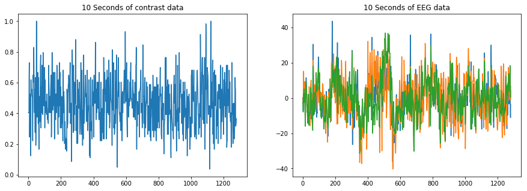

```python
plt.figure(figsize=(15,5))
plt.subplot(121)
plt.plot(contrast_level[: 10 * Fs.item()])
plt.title('10 Seconds of contrast data')
plt.subplot(122)
plt.plot(EEG[: 10 * Fs.item(), [10, 30, 40]])
plt.title('10 Seconds of EEG data')
```

### Calculating a TRF

As described in the introduction our goal is now in the forward model, find the function, that when convolved with the contrast data creates the EEG.

Using the toolbox this is fairly simple:

```python
[w, t, i] = mtrf_train(contrast_level, EEG, 128, 1, -150, 450, 1)
```

```python
print(f'There are three outputs, the model coeffecients w, shape={w.shape}')
print(f'The model time lags in use t, shape={t.shape}')
print(f'And a bias term i, shape={i.shape}')
```

```
There are three outputs, the model coeffecients w, shape=(1, 79, 128)
The model time lags in use t, shape=(79,)
And a bias term i, shape=(1, 128)
```

We see that we have a matrix of coefficients for each channel in the EEG and for each time lag created by the function (i.e. between -150, 450). Note, that if we would have used more complex data as an input (for example several contrast levels), the first dimension of w would change accordingly.

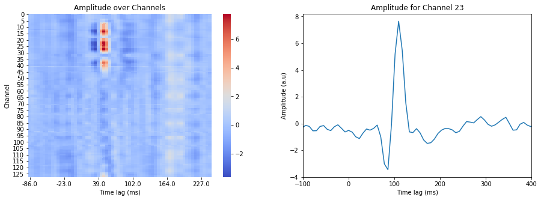

```python
plt.figure(figsize=(15,5))
ax = plt.subplot(121)
ax = sns.heatmap(w[0,8:72].T, xticklabels=12, ax=ax, cmap='coolwarm')
ax.set_xticklabels(np.round(t[9:71:8]))
plt.ylabel('Channel')
plt.xlabel('Time lag (ms)')
plt.title('Amplitude over Channels')

plt.subplot(122)
plt.plot(t, w[0][:, 22])
plt.ylabel('Amplitude (a.u)')
plt.xlabel('Time lag (ms)')
plt.xlim([-100, 400])
plt.title('Amplitude for Channel 23')
```

On the left, we see the a heatmap of the fitted weights. On the right, there is the TRF that was estimates for channel 23.